# Basic data visualization with ggplot2

Joshua French

2022-09-13

This document is intended to help you quickly learn how to perform basic data visualization using **ggplot2**.

An accompanying YouTube playlist that walks through this document is available by following the link [here](https://youtube.com/playlist?list=PLkrJrLs7xfbVbI1WHs8FfkOoFvtiI6EXd). I have also included direct, relevant video links throughout the file (e.g., immediately after the the relevant heading). An html version of this document can be downloaded to your current working direction (run `getwd()` in the Console to see where this is) by running the following command:

```r
download.file("https://raw.githubusercontent.com/jfrench/DataWrangleViz/master/03-basic-data-viz-with-ggplot2.nb.html",
              "03-basic-data-viz-with-ggplot2.nb.html")
```

The raw R Markdown code used to generate the html file can be obtained by toggling the “Code” box in the upper-right corner of the html file and selecting “Download Rmd”.

# Basic data visualization with **ggplot2** (Video: [YouTube](https://youtu.be/9F-4q-sI3sI), Panopto)

In this chapter we discuss how to perform basic data visualization.

Data graphics should be as *informative* as possible.

- Graphics do *not* need to contain as much *information* as possible.
- Make it as easy as possible to understand the information you want to reveal about the data.

In general, simpler graphics are easier to understand and should be preferred. However, adding complexity to a graphic can sometimes reveal far more about the data than a simple graphic. You will have to decide what is needed in a graphic to make it as informative as possible.

Be careful to not to include too much information in a single graphic. Complicated graphics may present far more information than we are able to process. We’ll see some examples of this later.

We will use **ggplot2** (Wickham 2016) to construct the graphics in this chapter. **ggplot2** has become increasingly popular for producing flexible graphics within an elegant framework.

We start by loading the **ggplot2** package.

```r
library(ggplot2)
```

## Graphics ecosystems in R ([Graphics ecosystems video](https://youtu.be/R12YAjSze0I))

There are three main graphics ecosystems in R:

1. **base**
2. **lattice**
3. **ggplot2**

**base** graphics are traditional S-like graphics.

- Run `?graphics-package` in the Console for more details.
- These are the graphics you get by default when you use the `plot` function, the `hist` function, the `boxplot` function, etc.

**lattice** graphics are an implementation of Trellis graphics (Becker, Cleveland, and Shyu 1996) for R.

- Run `?lattice` in the Console for additional information about the **lattice** package.
- The **lattice** package focuses on elegantly plotting multivariate data and makes it easy to distinguish different levels of `factor` data.
- **lattice** and **base** graphics do not interact with each other (changing aspects of one graphics system has no impact on the other.)

**ggplot2** is a layered graphical system based on implementing the Grammar of Graphics (Wilkinson 2005).

- It has gained widespread popularity because of its friendliness for visual exploration of data by data scientists.
- It provides an elegant approach for constructing complex plots in a systematic way.
- Run `?ggplot2-package` in the Console for more information.

We demonstrate use of the three plotting ecosystems using the `penguins` data set from the **palmerpenguins** package (Horst, Hill, and Gorman 2020), which will be discussed in more detail later. The code below creates grouped scatter plots comparing bill length (mm) and body mass (g) of different penguin species using each of the ecosystems.

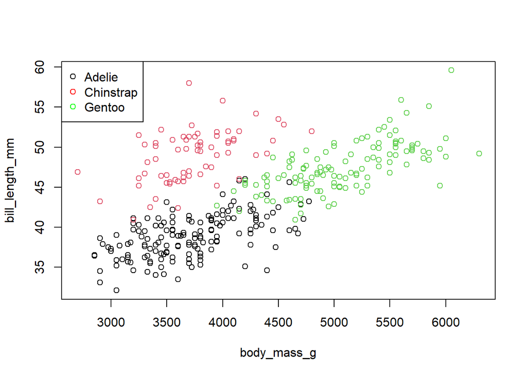

```r
# load data
data(penguins, package = "palmerpenguins")
# base graphics
plot(bill_length_mm ~ body_mass_g, data = penguins, col = penguins$species)
legend(x = "topleft", legend = levels(penguins$species), col = c("black", "red",
    "green"), pch = 1)
```

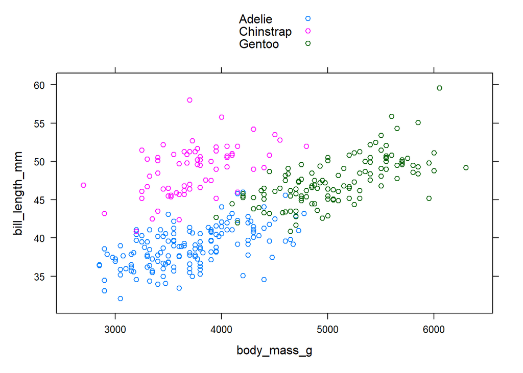

```r
# lattice graphics
lattice::xyplot(bill_length_mm ~ body_mass_g, data = penguins, group = species, auto.key = TRUE)
```

```r
# ggplot2 graphics
ggplot2::ggplot(data = penguins) + ggplot2::geom_point(mapping = aes(x = body_mass_g,
    y = bill_length_mm, color = species, shape = species))
```

[output not shown]

## Basic ingredients ([Basic ingredients video](https://youtu.be/k6a3vMoBXSw))

There are 4 main components needed to produce a graphic using **ggplot2**.

1. A data frame containing your data.
   - Each column should be a variable and each row should be an observation of data.
2. A `ggplot` object.
   - This is initialized using the `ggplot` function.
3. A geometric object.
   - These are called “geoms” for short.
   - geoms indicate the geometric object used to visualize the data. E.g., points, lines, polygons etc. More generally, geoms indicate the type of plot that is desired, e.g., histogram, density, or boxplot, which aren’t exactly a simple geometric argument.
4. An aesthetic.
   - An aesthetic mapping indicates what role a variable plays in the plot.
   - e.g., which variable will play the “x” variable in the plot, the “y” variable in the plot, control the “color” of the observations, etc.

In *R for Data Science*, Wickham and Grolemund (2017) provide the following template for creating graphics using **ggplot2**:

```r
ggplot(data = <DATA>) + <GEOM_FUNCTION>(mapping = aes(<MAPPINGS>))
```

`<DATA>`, `<GEOM_FUNCTION>`, and `<MAPPINGS>` are placeholders that you replace with the data frame, geometric object, and aesthetic mappings you want to use in your specific plot.

An explanation of the template above:

1. Every `ggplot` starts with a call to the `ggplot` function.
   - You can create a blank plot by running `ggplot()` in the Console.
2. Generally, you pass your data frame to the `ggplot` through the `data` argument.
   - You can also pass `data` inside the `<GEOM_FUNCTION>` when you intend to use multiple geometric objects with different data sources.
3. The `<GEOM_FUNCTION>` indicates the geometric object you want to use in the plot.
4. The `<MAPPINGS>` describes the aesthetics mappings you want to use for this particular geometry.
   - One of the reasons **ggplot2** is so powerful is that you can use different mappings for different geometric objects.
5. The `+` symbol is used to add a layer to your graphic.
   - If your code spans multiple lines, then you need to make sure all lines but the last end with the `+` operator to stack the layers properly.

### Some geometric objects

There are many geometric objects available in **ggplot2**. A complete list may be (currently) found at https://ggplot2.tidyverse.org/reference/. A partial list of geometric objects that I frequently use is found below in Table 1.

Table 1: Common geometries provided by **ggplot2**.

| data_dimensionality | geometry | purpose |
| --- | --- | --- |
| 1d | `geom_bar` | Draws a bar chart. |
| 1d | `geom_density` | Draws a density plot. |
| 1d | `geom_histogram` | Draws a histogram. |
| 1d | `geom_boxplot` | Draws a boxplot. |
| 1d | `geom_violin` | Draws a violin plot. |
| 1d | `geom_qq` | Draws a quantile-quantile plot. |
| 2d | `geom_point` | Draws points. Used for scatter plots. |
| 2d | `geom_path`, `geom_line` | Connects observations. Used for line plots. |
| 2d | `geom_segment` | Draws straight lines between points. |
| 2d | `geom_curve` | Draws curved lines between points. |
| 2d | `geom_smooth` | Draws a ‘smooth’ fitted model of the data. |
| 2d | `geom_density2d` | Draws 2d contours of density estimate for two variables. |
| 2d | `geom_density2d_filled` | Draws 2d contours of density estimate for two variables with colors. |
| 3d | `geom_contour` | Draws 2d contours of 3d data. |
| 3d | `geom_contour_filled` | Draws 2d contours of 3d data (colored). |
| NA | `geom_abline`, `geom_hline`, `geom_vline` | Draws diagonal, horizontal, and vertical lines. |

### Some aesthetic mappings

Aesthetic mappings are unique to each geometric object. Some of the most common ones that show up in many geoms are provided below in Table 2.

Table 2: Common aesthetics provided by **ggplot2**.

| aesthetic | purpose |
| --- | --- |
| `x` | Controls the x-variable in the plot. |
| `y` | Controls the y-variable in the plot. |
| `alpha` | Controls the transparency of the object. |
| `color`, `colour` | Controls the colors of the object. |
| `fill` | Controls the color of the interior of an object. |
| `group` | Controls how the data are grouped. |
| `linetype` | Controls the type of line used to draw the object. |
| `size` | Controls the size of the drawn object. |
| `shape` | Controls the shape of the object. |

## Simple examples

### The `penguins` data ([Introducing the penguins data video](https://youtu.be/XpsV65um6Uc))

We will use the `penguins` data set in the **palmerpenguins** package (Horst, Hill, and Gorman 2020) to illustrate some of the ways that **ggplot2** can be used.

The `penguins` data set provides data related to various penguin species measured in the Palmer Archipelago (Antarctica), originally provided by Gorman, Williams, and Fraser (2014). We start by loading the data into memory.

```r
data(penguins, package = "palmerpenguins")
```

The data set includes 344 observations of 8 variables. The variables are:

- `species`: a `factor` indicating the penguin species
- `island`: a `factor` indicating the island the penguin was observed
- `bill_length_mm`: a `numeric` variable indicating the bill length in millimeters
- `bill_depth_mm`: a `numeric` variable indicating the bill depth in millimeters
- `flipper_length_mm`: an `integer` variable indicating the flipper length in millimeters
- `body_mass_g`: an `integer` variable indicating the body mass in grams
- `sex`: a `factor` indicating the penguin sex (`female`, `male`)
- `year`: an integer denoting the study year the penguin was observed (`2007`, `2008`, or `2009`)

### Bar chart ([Bar charts video](https://youtu.be/cBwC1SKz_gA))

We construct a bar chart of the `species`. A bar chart uses bars to indicate the number of values each level of a `factor` includes. Alternatively, the bars can indicate the relative frequency (i.e., proportion) of values having each level of the `factor`.

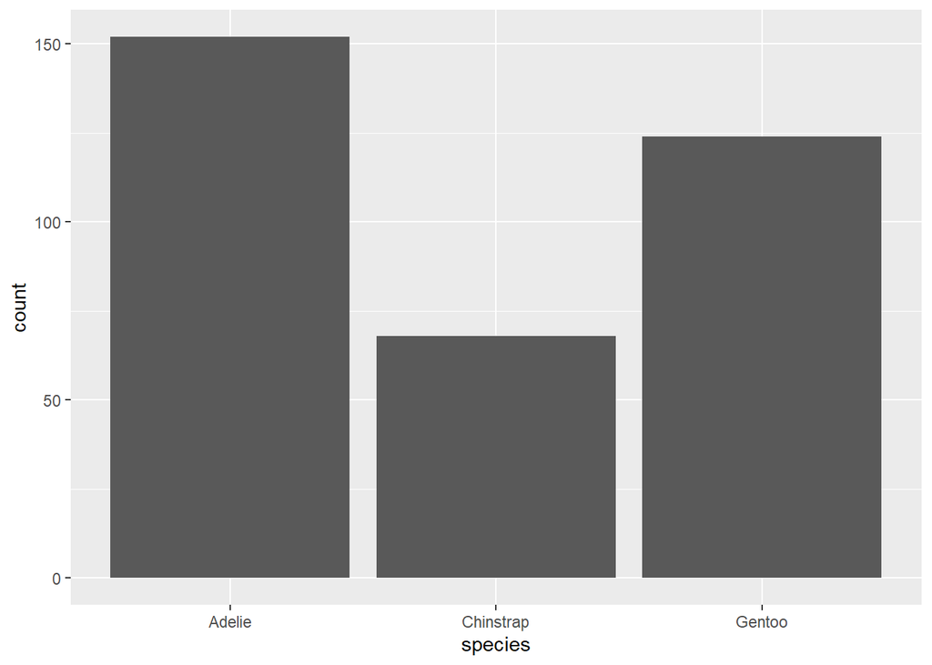

```r
ggplot(penguins) + geom_bar(aes(x = species))
```

Relatively speaking, we can see that Adelie penguins were most frequently observed, followed by Gentoo penguins, and then Chinstrap penguins.

We can color the bars by `species` for visual clarity by specifying the `fill` aesthetic.

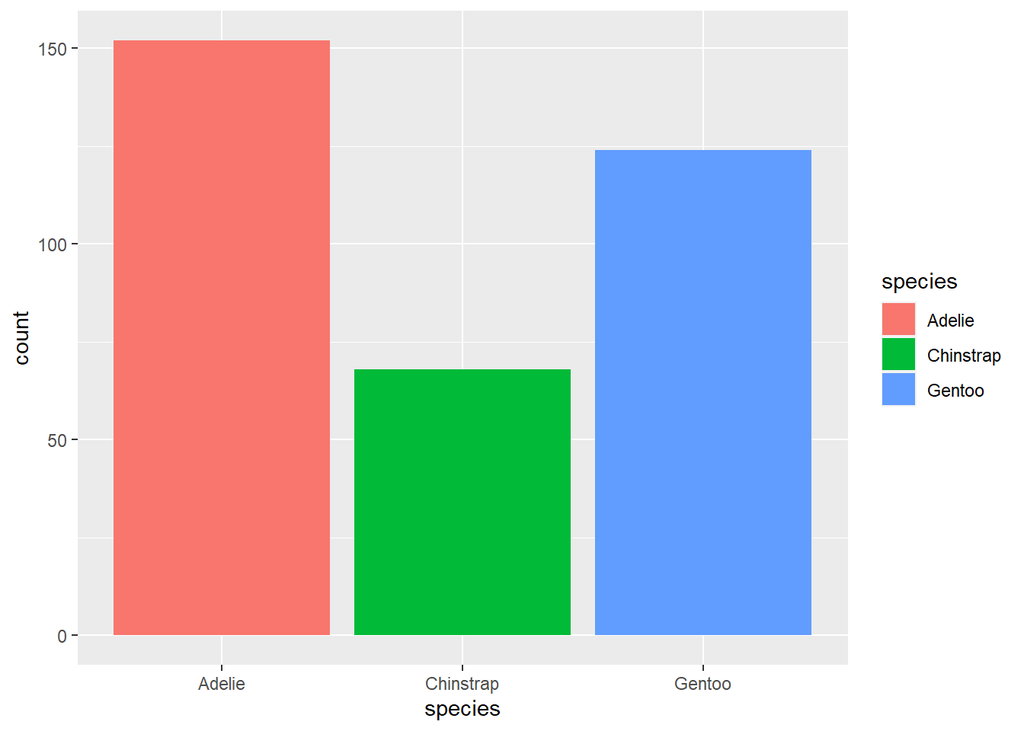

```r
ggplot(penguins) + geom_bar(aes(x = species, fill = species))
```

This doesn’t add any new information to the graphic but does make it more visually appealing. We could remove the legend to simplify the graphic, if we wanted.

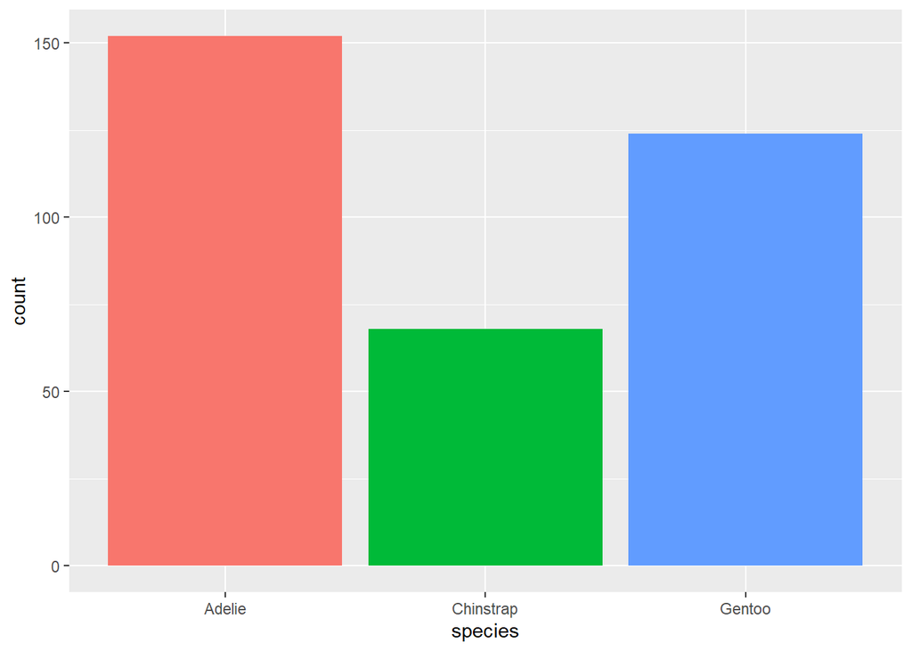

```r
ggplot(penguins) + geom_bar(aes(x = species, fill = species)) + theme(legend.position = "none")
```

### Histogram ([Histogram video](https://youtu.be/gFZpBO38HUg))

A *histogram* is used to display the distribution of a continuous `numeric` variable. The range of the variable is partitioned into classes. The number of observations falling in each class is counted. A histogram draws a bar for each class with height corresponding to the number of observations in that class.

Let’s construct a histogram of bill length.

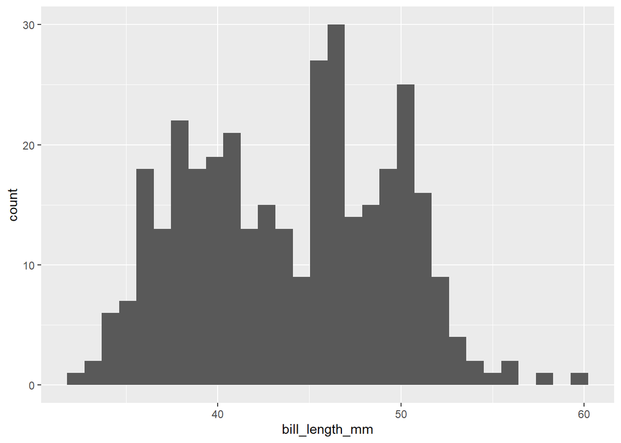

```r
ggplot(penguins) + geom_histogram(aes(x = bill_length_mm))
```

The histogram is multimodal (i.e., has multiple prominent peaks), having 2 or 3 prominent peaks. There may be sub-populations we should distinguish. It isn’t easy to identify sub-populations with histograms unless the sub-populations are split into separate histograms (which we will learn to do later with “facets”) or to make the bars semi-transparent for the different sub-populations.

### Density plot ([Density plots and scaling video](https://youtu.be/UGeJ73k6BGs))

A density plot is often preferred to a histogram because it’s more flexible, though it often provides similar information. A density plot is essentially a smoothed version of a histogram.

A density plot is appropriate for displaying the distribution of a continuous `numeric` variable and indicates the values for which the data is more “dense”. More specifically, density plots indicate the values of data you are most likely to observe. A higher density region means you are more likely to observe data with values in that region. There is a statistical definition we will not go into.

A simple density plot is shown below. We can’t learn a lot because of the sub-populations previously mentioned.

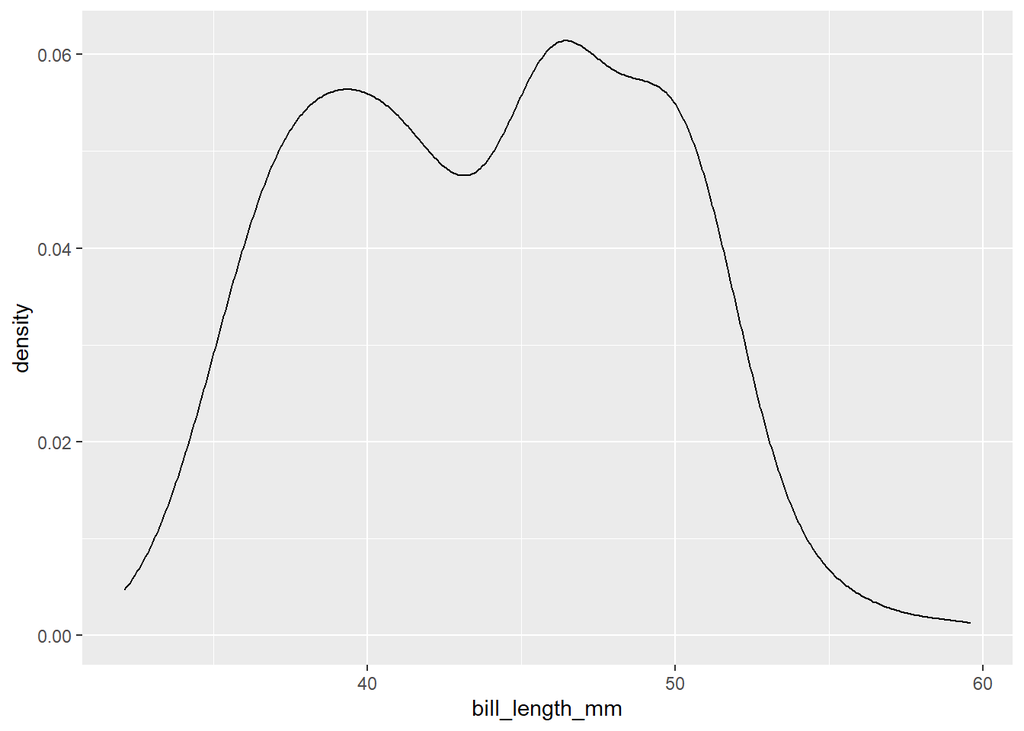

```r
ggplot(penguins) + geom_density(aes(x = bill_length_mm))
```

There are at least two modes in the `bill_length_mm` density plot.

Let’s create separate densities for the different penguin species by specifying the `color` aesthetic to *scale* different colors to the different levels of `species`.

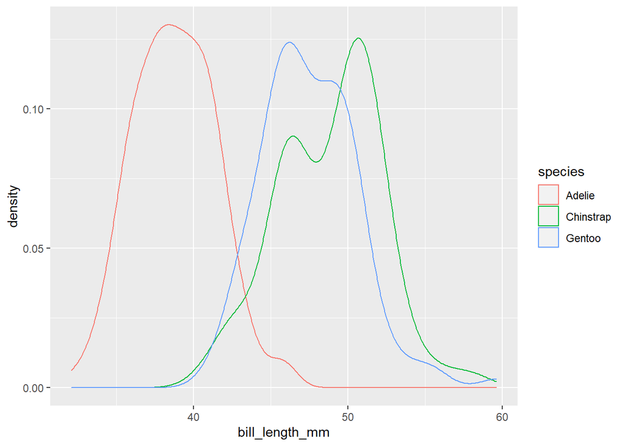

```r
ggplot(penguins) + geom_density(aes(x = bill_length_mm, color = species))
```

A weakness of the previous graphic is that the legend distinguishing the different `species` is a bit subtle. The colored line around the border may not be easy to distinguish for everyone. We could use a different `linetype` for each species or we could use different `color` and `linetype` for each species. We consider the different results below.

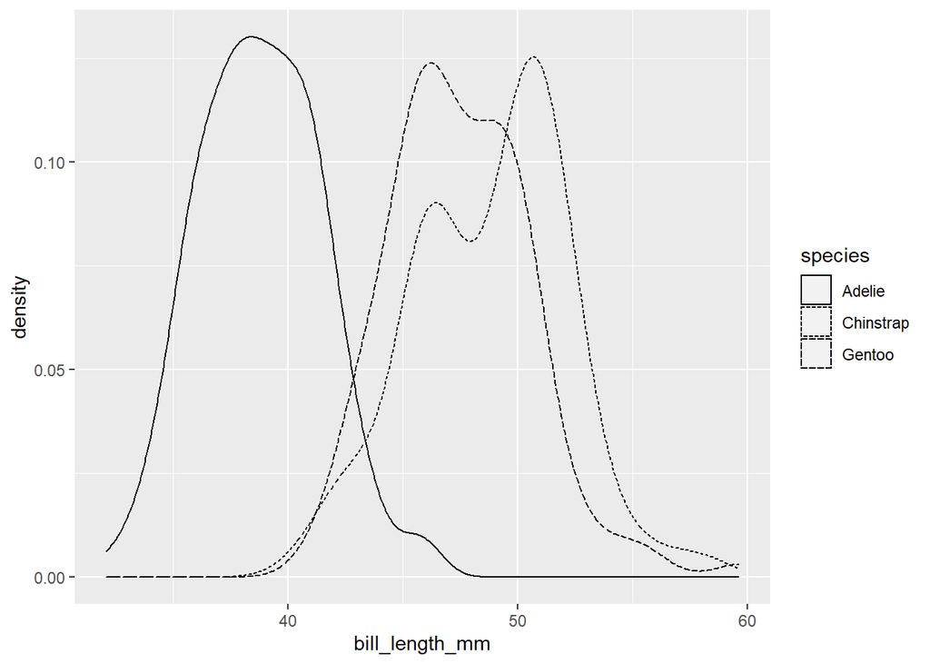

```r
ggplot(penguins) + geom_density(aes(x = bill_length_mm, linetype = species))
```

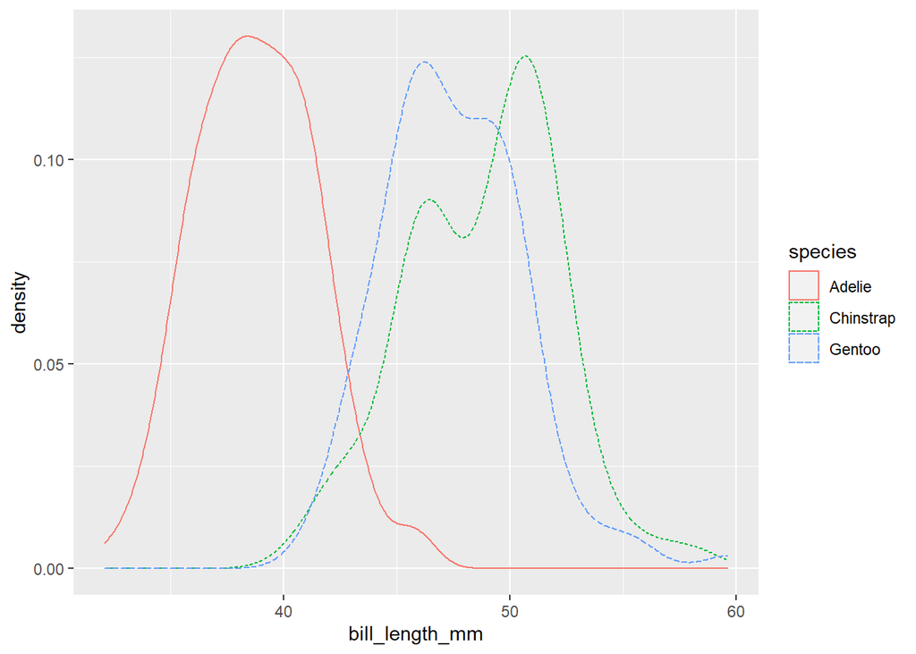

```r
ggplot(penguins) + geom_density(aes(x = bill_length_mm, col = species, linetype = species))
```

An even better option is to `fill` the densities for each species with different colors. However, the density curves will overlap, masking some of the information.

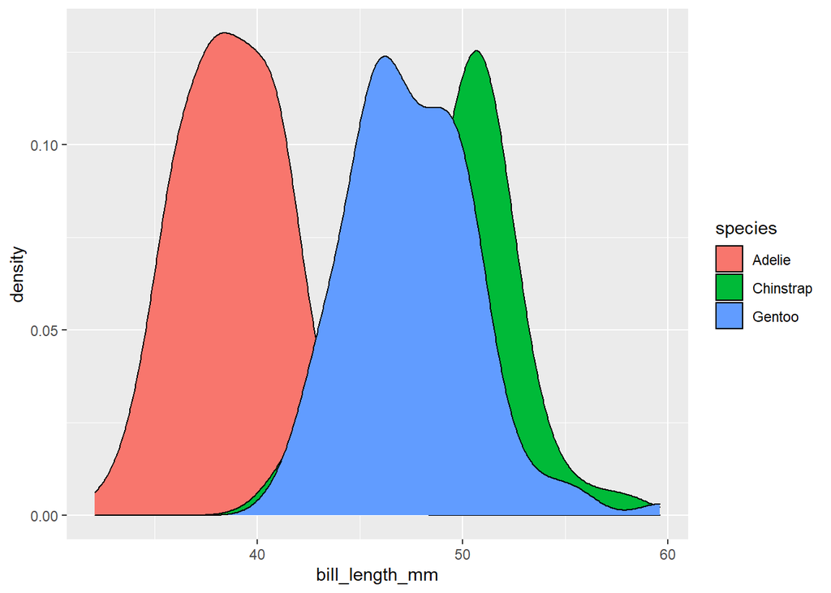

```r
ggplot(penguins) + geom_density(aes(x = bill_length_mm, fill = species))
```

To address the masking issue, we can control the transparency of the colors using the `alpha` aesthetic. This value, between 0 and 1, controls how transparent the objects are. `0` means transparent, `1` means completely opaque. We will set `alpha = 0.3`. Notice that we specify this OUTSIDE the aesthetic mapping since we are controlling the aesthetic manually instead of having **ggplot2** *scale* the provided variable.

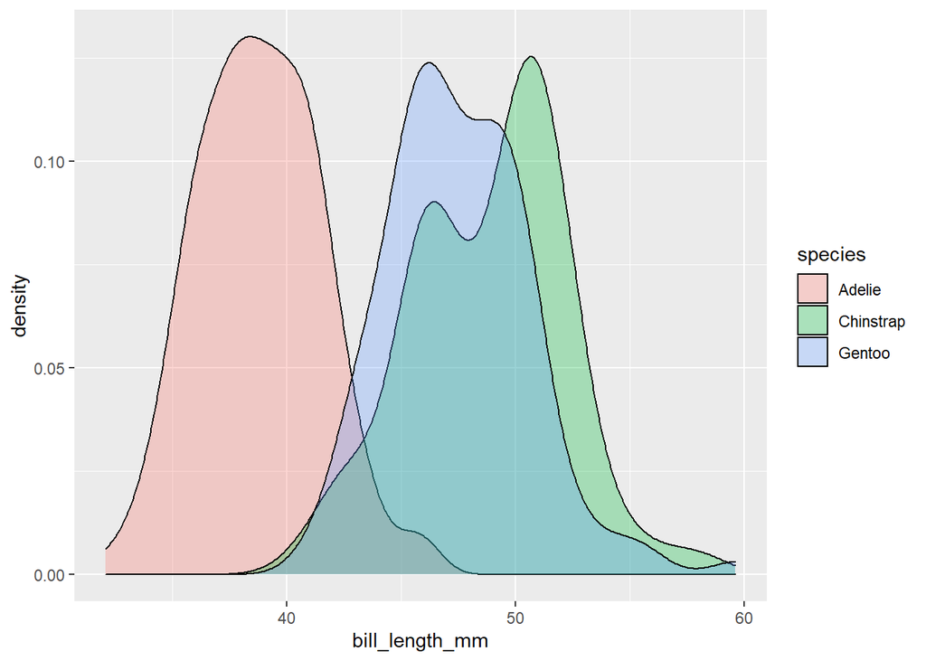

```r
ggplot(penguins) + geom_density(aes(x = bill_length_mm, fill = species), alpha = 0.3)
```

### Scaling

When a variable is mapped to an aesthetic, **ggplot2** will assign a unique value to each unique level of the variable. This process is known as *scaling*.

Scaling is often not very exciting, but it can be important when customizing the look of a `ggplot`.

When a variable is mapped to a non `x` or `y` aesthetic, **ggplot2** will automatically add a legend to indicate how the variable was scaled.

### Boxplots ([Boxplots video](https://youtu.be/EZjkg_hsh-w))

A boxplot is a robust display of information for a continuous `numeric` variable. Boxplots are robust because they rely on robust statistics not easily affected by outliers.

In general, a boxplot:

- Draws a box extending from Q1 (the 0.25 quantile) to Q3 (the 0.75 quantile) of the data.
- A line between Q1 and Q3 indicates the median (the 0.5 quantile) of the data.
- A “whisker” extends from Q1 to the smallest observation that is not an outlier.
- A “whisker” extends from Q3 to the largest observation that is not an outlier.
- An **outlier** is typically defined as an observation smaller than Q1 - 1.5 (Q3 - Q1) or larger than Q3 + 1.5 (Q3 - Q1).

Parallel boxplots are an effective tool for comparing differences between a variable across multiple levels of a `factor` variable.

Consider parallel boxplots of bill length distinguished by `species`.

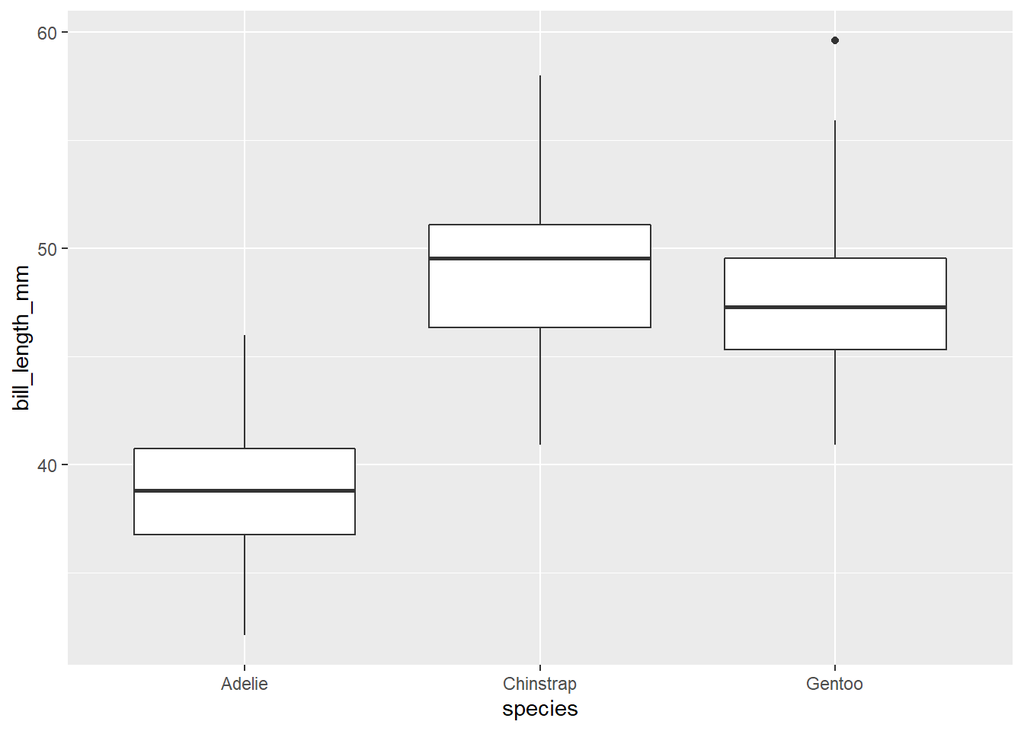

```r
ggplot(penguins) + geom_boxplot(aes(y = bill_length_mm, x = species))
```

We can see that the typical responses for the Adelie penguins tend to be lower than for the Chinstrap and Gentoo penguins. The Chinstrap penguins tend to have slightly longer beaks that the Gentoo penguins. All three penguins species seem to have similar variability (i.e., the spread of the data is similar).

A weakness of boxplots is that they throw away a lot of information. e.g., We don’t see the two sub-populations in the Chinstrap penguins that we noticed earlier when looking at density plots.

Adding a `fill` color to the boxplots (while removing the legend) might be a more visually appealing graphic.

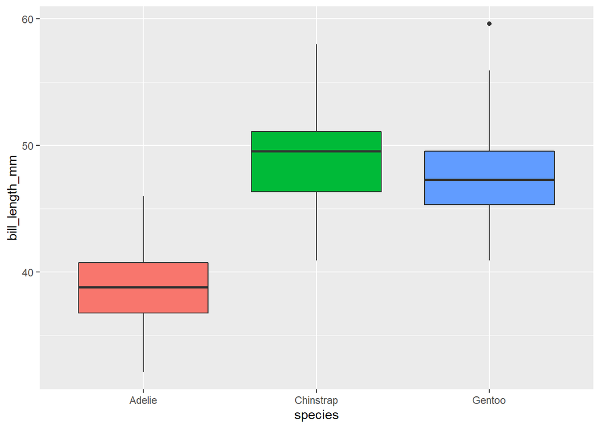

```r
ggplot(penguins) + geom_boxplot(aes(y = bill_length_mm, x = species, fill = species)) +
    theme(legend.position = "none")
```

### Violin plots ([Violin plots video](https://youtu.be/QbVWcjxYgHY))

A violin plot is like a cross between a boxplot and a density plot. A violin plot unites a density with its mirror image and then displays the unified object like a boxplot.

We construct violin plots of bill length for each penguin `species`.

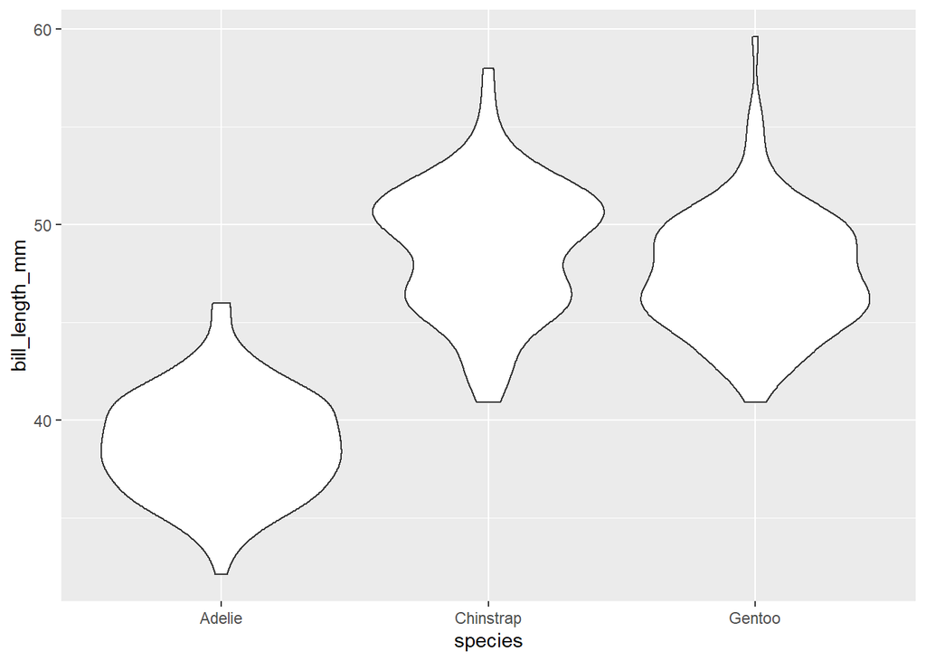

```r
ggplot(penguins) + geom_violin(aes(x = species, y = bill_length_mm))
```

### Scatter plots ([Scatter plots and scaling video](https://youtu.be/DjORoUDMLD4))

A scatter plot draws the locations of (x, y) positions based on two `numeric` variables. In general, we use scatter plots to learn information about the *association* between the two variables.

- A positive association is present when both variables tend to increase together.
- A negative association is present when one variable tends to decrease when the other increases.
- A linear association is present when the relationship between the two variables is a straight line.
- A nonlinear association is present when the relationship between the two variables is a curve.
- It is possible that no clear association is present in the data.

Let’s consider a scatter plot of `bill_length_mm` versus `body_mass_g`.

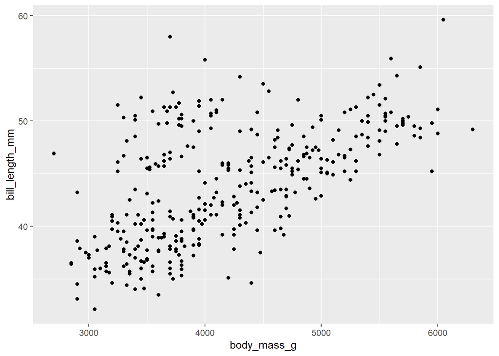

```r
ggplot(penguins) + geom_point(aes(x = body_mass_g, y = bill_length_mm))
```

We see a positive association in the graphic above. As `body_mass_g` increases, `bill_length_mm` also tends to increase. However, it appears that there may be some observations in the upper left part of the graph that do not match the overall linear trend.

This could mean:

1. The data are *noisy*, which simply means the patterns aren’t as strong and clear as we would like.
2. There is a third variable that not accounted for in our plot but that has a relationship with the other two variables.
   - When we are not accounting for this variable, it is called a *lurking variable*.
   - When we account for a lurking variable in our analysis, it becomes a *confounding variable*.
   - We are defining lurking and confounding variables in a general sense and not with statistical rigor.

Let’s consider an analysis of `body_mass_g` and `bill_length_mm` that accounts for `species`. Specifically, we will use the `color` aesthetic so that each penguin species is shown in a different color.

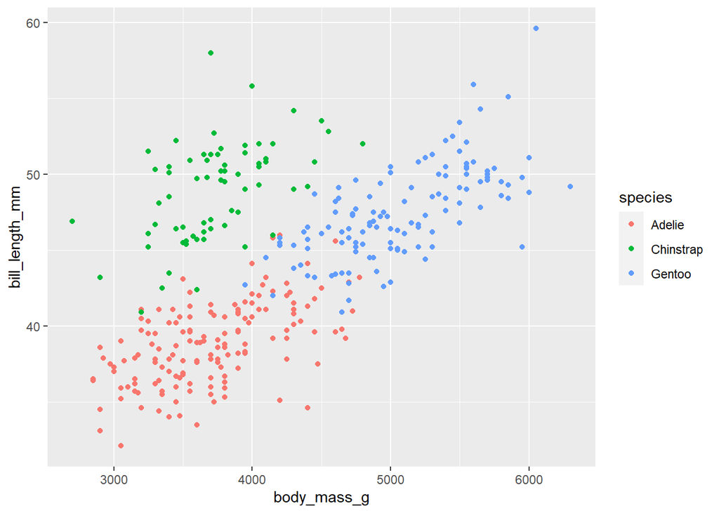

```r
ggplot(penguins) + geom_point(aes(x = body_mass_g, y = bill_length_mm, color = species))
```

As previously mentioned, we want our plots to be as clear as possible. Some individuals have difficulty interpreting colors in graphics. We can add another distinguishing characteristic for the different species. In this case, we will change the `shape` of the plotted points for each species. This provides another aid for correctly interpreting the graphic.

```r
ggplot(penguins) + geom_point(aes(x = body_mass_g, y = bill_length_mm, color = species,
    shape = species))
```

[output not shown]

### Adding smooths ([Adding smooths video](https://youtu.be/P2_qYBV1Byc))

A smooth in **ggplot2** is a model that that attempts to estimate the average relationship between a response variable (typically the `y` variable) and one or more predictor variables (typically the `x` and possibly other variables)

Adding a “smooth” to a plot can make relationships between variables even clearer. There are many different smoothing methods.

A smoothing layer can be added to a plot using `geom_smooth`. Many methods can be used for the smooth. **ggplot2** takes the methods `lm` (linear model), `glm` (generalized linear model), `gam` (generalized additive model), `loess` (local fitting), or a function (e.g., `MASS::rlm` for a robust linear model). If you don’t know what these are, do not add them to your plot because they won’t help you to explain the data.

A simple linear regression model fits the straight line that minimizes the squared deviations between the y values and the estimated line. We add simple linear regression line to the scatter plot by adding a `geom_smooth` layer.

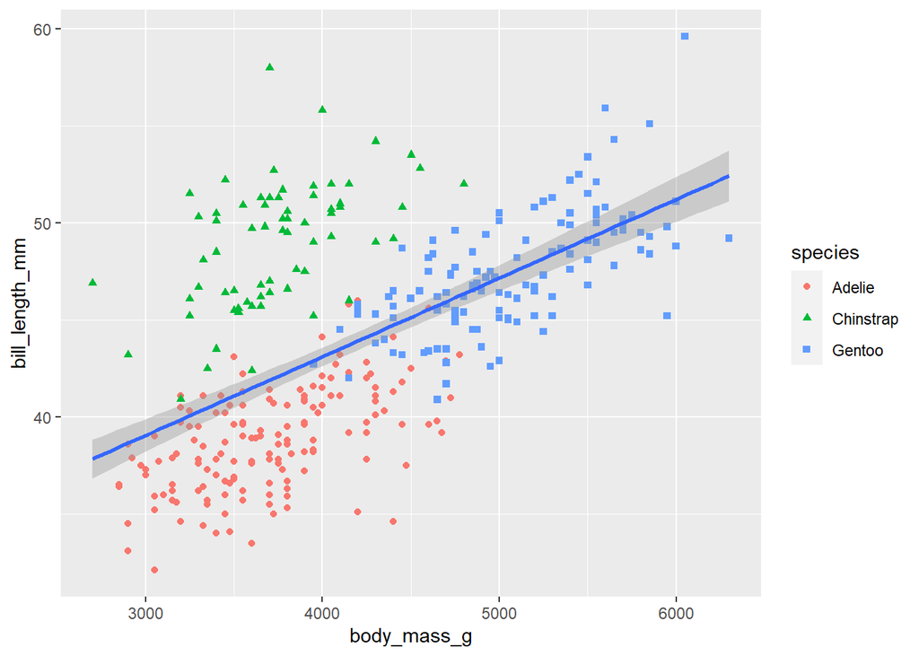

```r
ggplot(penguins) + geom_point(aes(x = body_mass_g, y = bill_length_mm, color = species,
    shape = species)) + geom_smooth(aes(x = body_mass_g, y = bill_length_mm), method = "lm")
```

This only adds a single line across all groups, which clearly doesn’t explain the relationship when accounting for `species`. To add a separate line for each `species`, we need to include that in the aesthetic mapping for `geom_smooth`. If we scale the `species` variable using the `color` aesthetic, then a simple linear regression line will be estimated for each species in the color that matches the scatter plot.

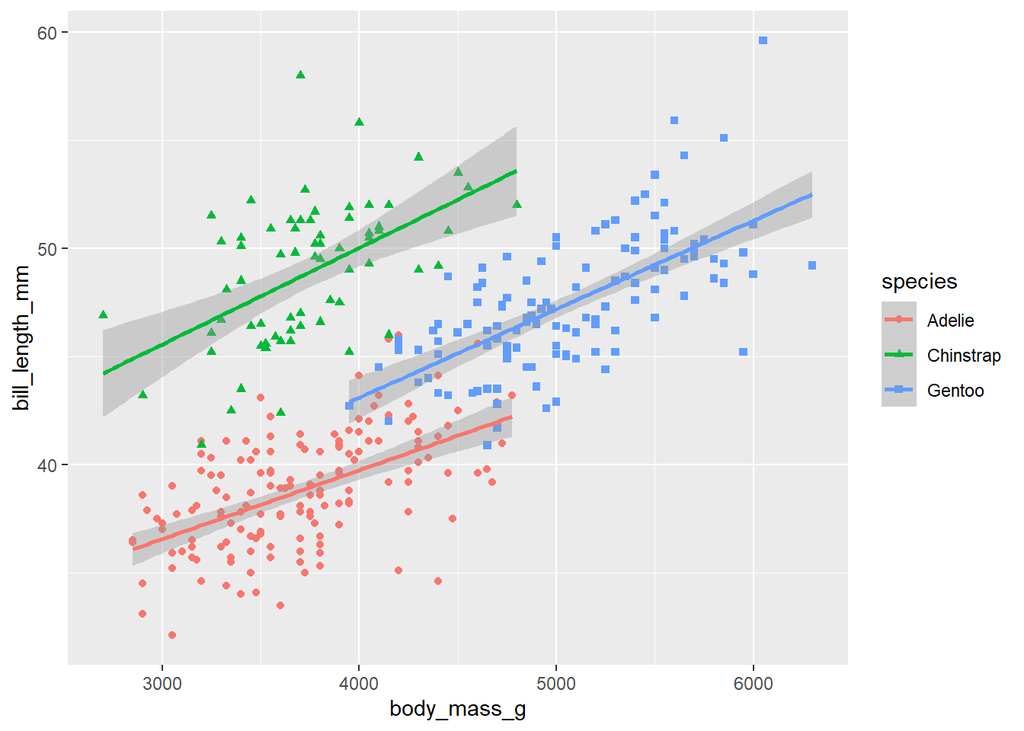

```r
ggplot(penguins) + geom_point(aes(x = body_mass_g, y = bill_length_mm, color = species,
    shape = species)) + geom_smooth(aes(x = body_mass_g, y = bill_length_mm, color = species),
    method = "lm")
```

### Using common aesthetics across geometries ([Common geometries video](https://youtu.be/oFWHATa7AQw))

Notice that we had to specify the aesthetic mappings in each geom. This seems redundant.

If you specify an aesthetic mapping in a geom, then the aesthetic mapping is *local* and only applies to that particular geom. If you want to specify a *global* aesthetic mapping that applies across all geoms, then you can specify the `mapping` in the `ggplot` function.

Here is a simpler version of the previous plot.

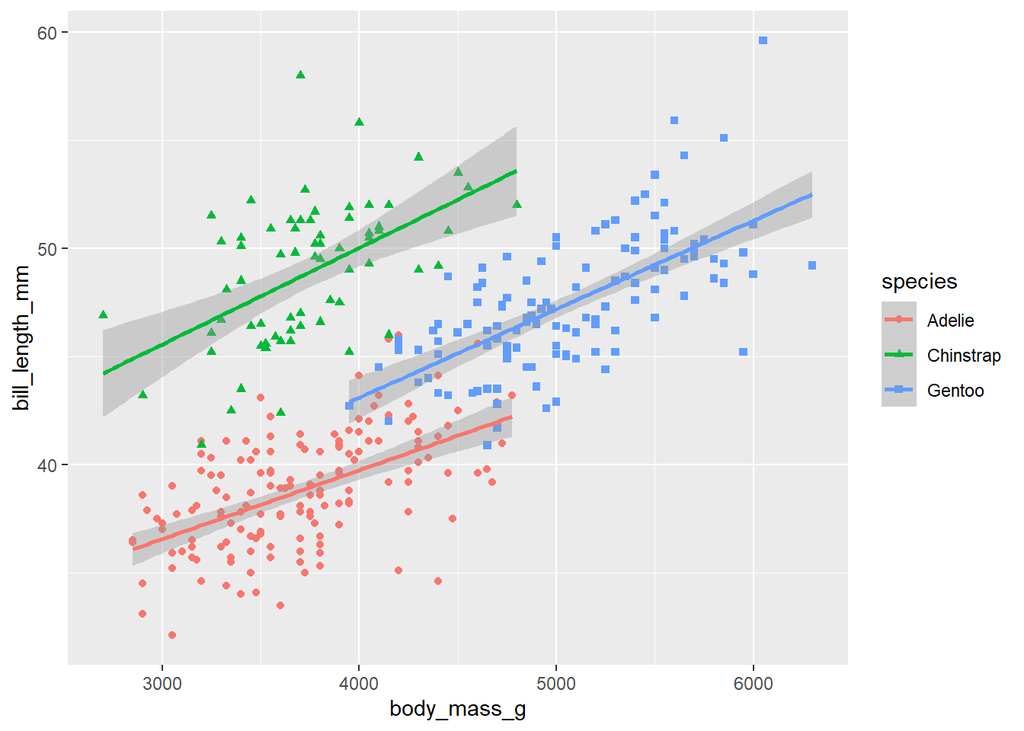

```r
ggplot(data = penguins, mapping = aes(x = body_mass_g, y = bill_length_mm, color = species)) +
    geom_point(aes(shape = species)) + geom_smooth(method = "lm")
```

## Customizing plots ([Customizing a ggplot video](https://youtu.be/Pe5r881J4p8))

Unsurprisingly, the graphics produced by **ggplot2** can be greatly customized. We consider some of the basic customizations below.

### Assigning a plot

One of the strengths of **ggplot2** is that you can easily build a plot layer by layer. In this case, it is useful to assign the current plot a name that can then be added to later.

Note: When you assign a `ggplot` a name, it will NOT be displayed, as is typical when assigning objects in R. You have to then print the object using the `print` function or by simply running the object name in the Console. Let’s assign the name `ggp` to the basic penguin scatter plot displaying bill length versus body mass, using colors and shapes to distinguish between different species.

```r
ggp <- ggplot(data = penguins, mapping = aes(x = body_mass_g, y = bill_length_mm,
    color = species)) + geom_point(aes(shape = species))
ggp
```

[output not shown]

We’ll customize this plot below.

### Axis labels and titles

The x-axis labels, y-axis labels, and title of a plot are controlled using the `xlab`, `ylab`, and `ggtitle` functions, respectively. Let’s customize the penguin scatter plot previously discussed. We’ll update the `ggp` object to include our improvements then print the result.

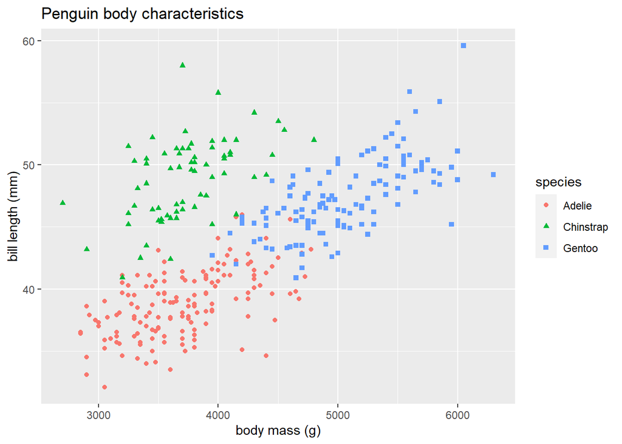

```r
ggp <- ggp + xlab("body mass (g)") + ylab("bill length (mm)") + ggtitle("Penguin body characteristics")
ggp
```

### Axis limits

The x-axis and y-axis limits are controlled using the `xlim` and `ylim` functions. Each function takes the lower and upper limit you want to set, e.g., `xlim(0, 100)`. Let’s change the axes for the penguin scatter plot previously discussed. There’s nothing wrong with the previous limits, but we’ll extend them a bit for demonstration.

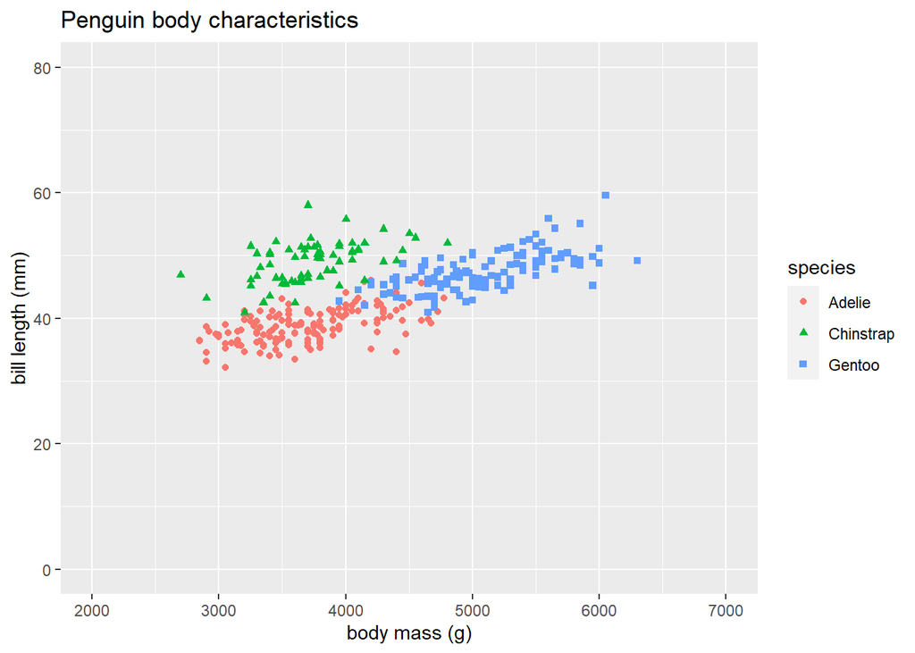

```r
ggp + xlim(2000, 7000) + ylim(0, 80)
```

### Manual aesthetics

Aesthetics can be set manually in a geom by specifying the aesthetic directly in the geom but outside the `aes` function. Let’s change the shape of the points for a scatter plot, increase the size of the points, and manually change the color of the points.

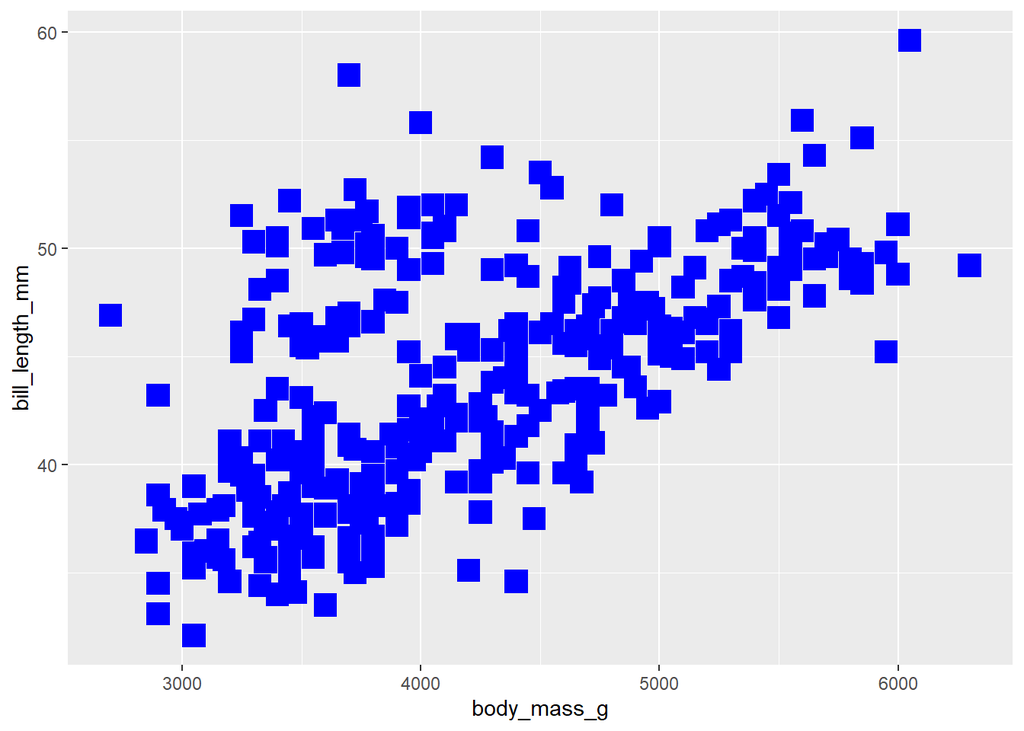

```r
ggplot(data = penguins) + geom_point(aes(x = body_mass_g, y = bill_length_mm), shape = 15,
    size = 5, color = "blue")
```

### Scale customization

*Scaling* is the name of the process used by **ggplot2** to map a variable to a unique value. This is particularly important for `factor` variables. For example, color scaling is the process by which the the `color` aesthetic is mapped to particular colors. These can be customized using the various `scale_*` functions, where the “*” is a placeholder for the rest of the function name.

Let’s manually set the color scaling using the `scale_color_manual` function. The colors provided below come from the *Dark2* color palette of the *qualitative* type provided by the ColorBrewer website (https://colorbrewer2.org/), which provides color advice. It’s particularly great for identifying colorblind-friendly color palettes.

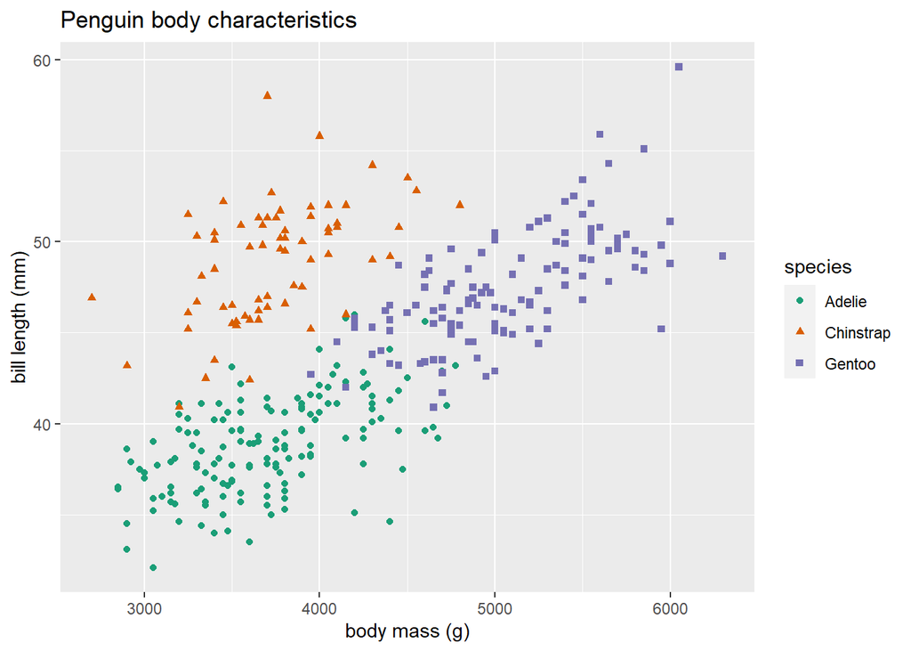

```r
ggp + scale_color_manual(values = c("#1b9e77", "#d95f02", "#7570b3"))
```

Alternatively, we could have used `scale_color_brewer` function instead, which automatically includes the color palettes desigend by Color Brewer. Run `?scale_color_brewer` for more details.

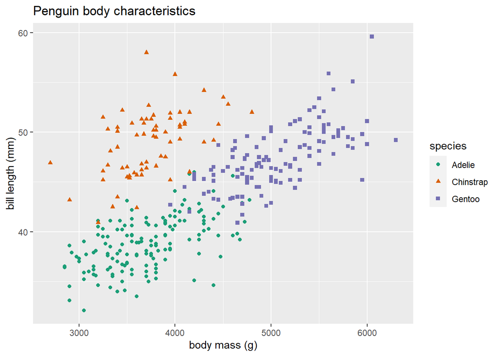

```r
ggp + scale_color_brewer(type = "seq", palette = "Dark2")
```

Scalings can be customized in many ways, but it quickly becomes complicated, so we don’t discuss them further.

### Legend customization

The legend can be customized in many ways. To move the location of the legend, you can specify the `legend.position` argument of the `theme` function.

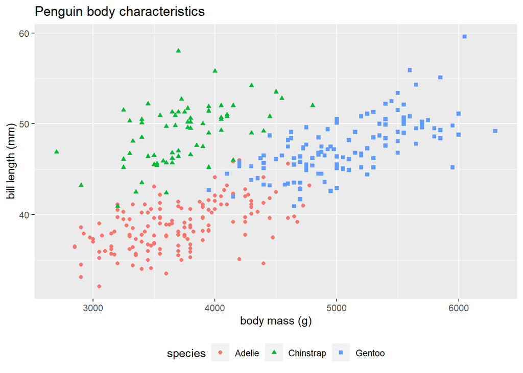

```r
ggp + theme(legend.position = "bottom")
```

You can customize legend size, background, names, colors, etc. For specific implementation details, it is probably best to do a web search.

### Themes

We will use the **patchwork** package (Pedersen 2022) to easily combine several plots into a single graphic. The **patchwork** package uses `()` to group a set of plots, `|` to separate plots horizontally, and `/` to stack sets of plots vertically.

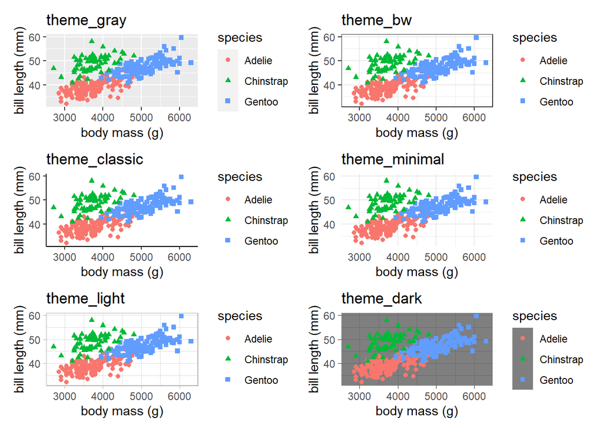

```r
ggp_gray <- ggp + theme_gray() + ggtitle("theme_gray")
ggp_bw <- ggp + theme_bw() + ggtitle("theme_bw")
ggp_classic <- ggp + theme_classic() + ggtitle("theme_classic")
ggp_minimal <- ggp + theme_minimal() + ggtitle("theme_minimal")
ggp_light <- ggp + theme_light() + ggtitle("theme_light")
ggp_dark <- ggp + theme_dark() + ggtitle("theme_dark")
library(patchwork)
(ggp_gray | ggp_bw)/(ggp_classic | ggp_minimal)/(ggp_light | ggp_dark)
```

These themes can be customized further by changing the appropriate aspects of the plots. We leave the user to use web searches for the desired customizations.

## Other components of a `ggplot`

### Facetting ([Facetting a ggplot video](https://youtu.be/6NGrEJ7phTA))

*Facetting* a data set creates separate plotting panels for each level of one or more discrete variables. Facetting is useful for examining patterns for combinations of levels for one or more discrete variables. Technically, facetting can be performed for `numeric` variables with a relatively small number of unique values, but for practical reasons, facetting is most appropriate for `factor` variables.

There are two functions for creating facetted graphics in **ggplot2**:

- `facet_wrap` facets the plots based on a single `factor` variable. The panels are wrapped around the plotting window.
- `facet_grid` forms a matrix of panels based on row and column facetting variables.

In the plot below, we facet scatter plots of `bill_length_mm` versus `body_mass_g` by `species`.

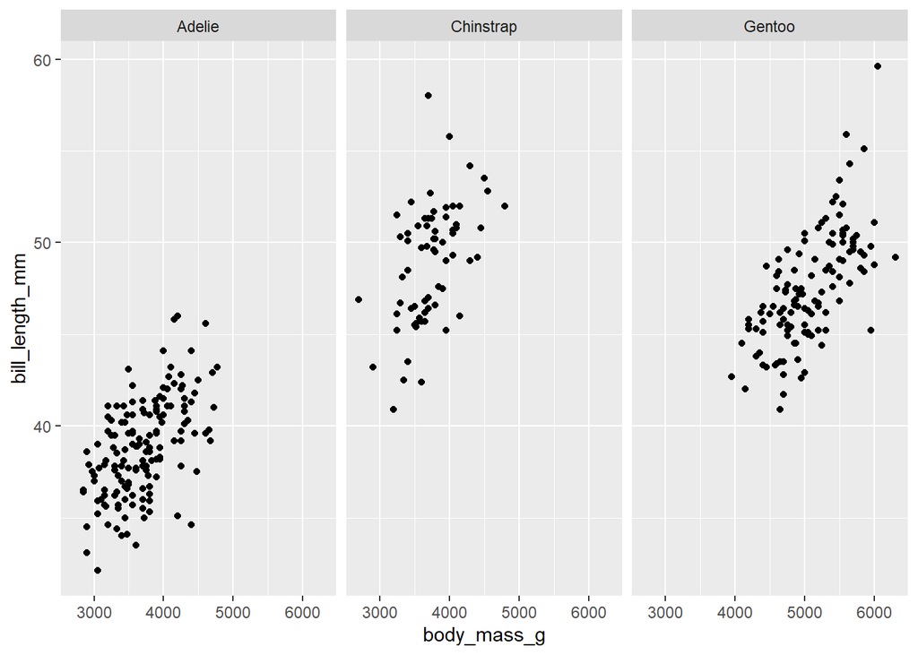

```r
ggplot(penguins) + geom_point(aes(x = body_mass_g, y = bill_length_mm)) + facet_wrap(~species)
```

By default, the same x and y axes are used in all panels. This is standard because it facilitates direct comparisons across panels. This can be customized using the `scales` argument of the `facet_*` functions. The allowable `scales` argument values are:

- `fixed`: same x and y axes for all panels. The default.
- `free`: individual x and y axes for each panel
- `free_x`: individual x axes for each panel, common y axis
- `free_y`: individual y axes for each panel, common x axis

We now consider use the `facet_grid` function to facet by two `factor` variables, `species` and `sex`. Prior to plotting, we remove the observations with `NA` for the `sex` variable.

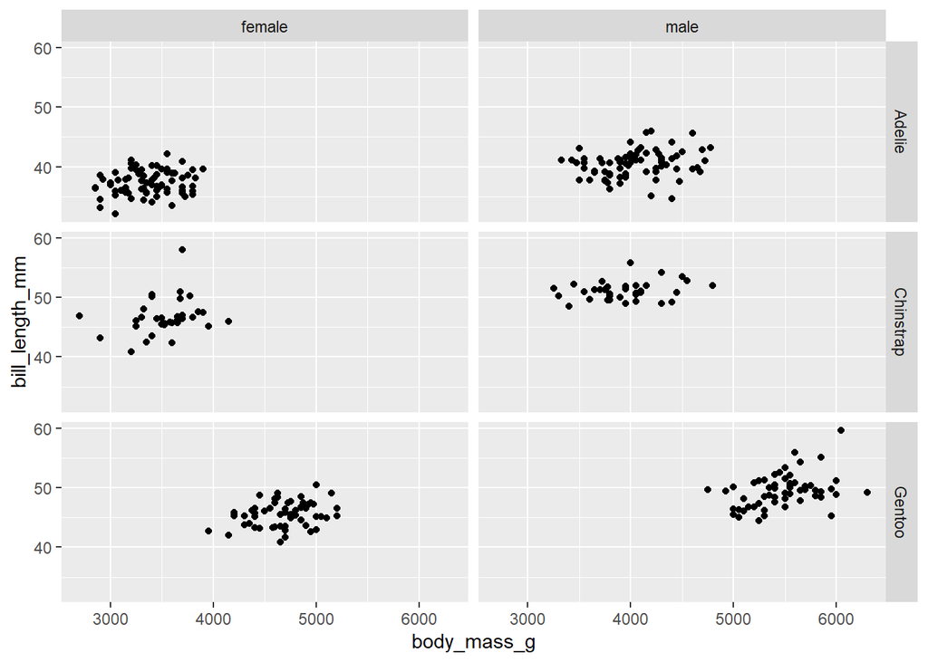

```r
ggplot(subset(penguins, !is.na(sex))) + geom_point(aes(x = body_mass_g, y = bill_length_mm)) +
    facet_grid(species ~ sex)
```

There appears to be differences in the sizes of the male and female penguins, bit it is difficult to compare the patterns across panels. It may be more useful to facet by `species` but distinguish by `sex` in a single panel.

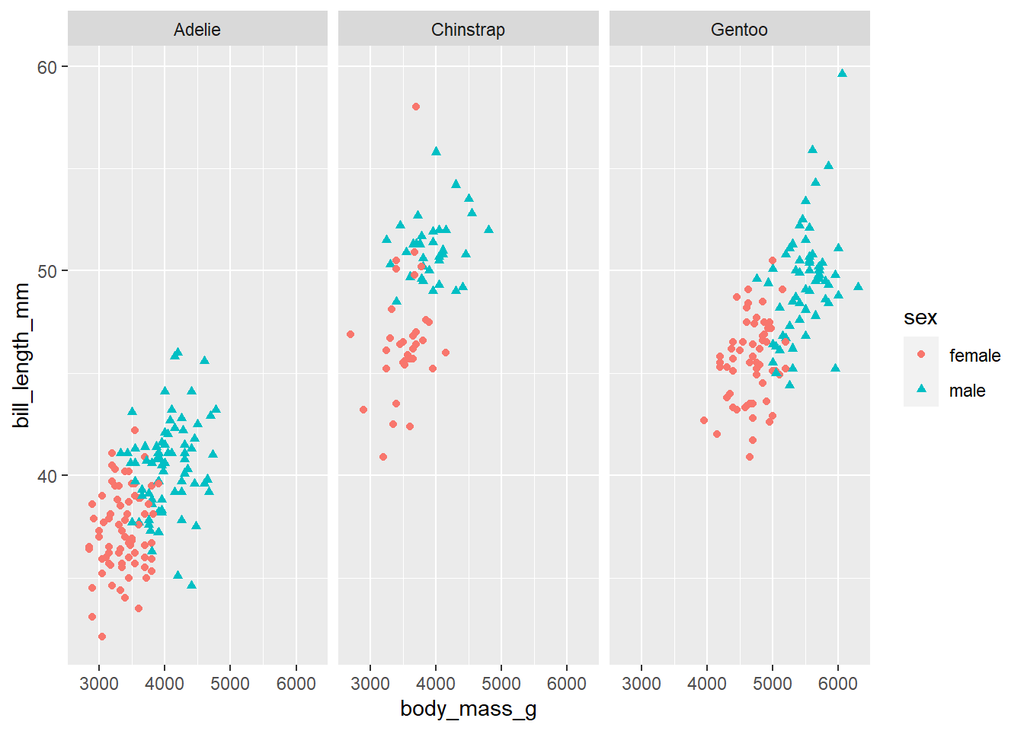

```r
ggplot(subset(penguins, !is.na(sex))) + geom_point(aes(x = body_mass_g, y = bill_length_mm,
    color = sex, shape = sex)) + facet_wrap(~species)
```

It is clear now that across species, the males tend to have greater body mass and bill length in comparison to the females.

### Statistical transformations ([`stat` argument video](https://youtu.be/ia7CZEBgoKc))

*Statistical transformations* are the process that **ggplot2** uses to summarize the data before plotting. By default, every geom uses a default `stat` argument that summarizes the data before plotting. Perhaps surprisingly, every `stat_*` has a default `geom` argument to specify how the summarized data should be plotted.

In general, you can simply learn to use the geom that summarizes and plots the data to your liking. Depending on the data you have, sometimes you may want to specify a different `stat` argument. In general, custom `stat` arguments are beyond the scope of this tutorial.

However, we do consider a simple example involving bar charts.

By default, `geom_bar` uses `stat_count` to count the number of values having each level of a `factor` variable and then plots the height of each bar above the names of the `factor` levels.

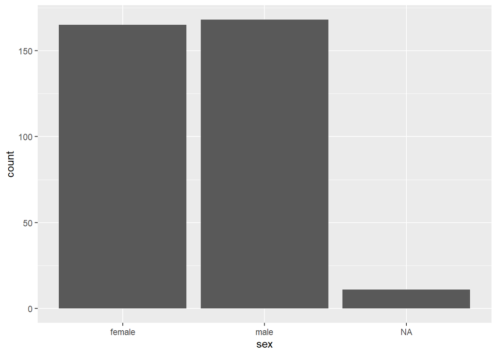

```r
ggplot(penguins) + geom_bar(aes(x = sex))
```

However, let’s suppose our data frame already has counts for the number of values in each level. In the case, we must change the `stat` argument for `geom_bar` to `"identity"` (for `stat_identity`). We do this in the example below, where we also have to clearly indicate the `x` variable and the `y` variable in the plot.

```r
# count values with each level
penguins_count <- as.data.frame(table(penguins$sex, useNA = "ifany"))
# rename variales
names(penguins_count) <- c("sex", "count")
# print data frame
penguins_count
```

| sex | count |
| --- | --- |
| female | 165 |
| male | 168 |
| NA | 11 |

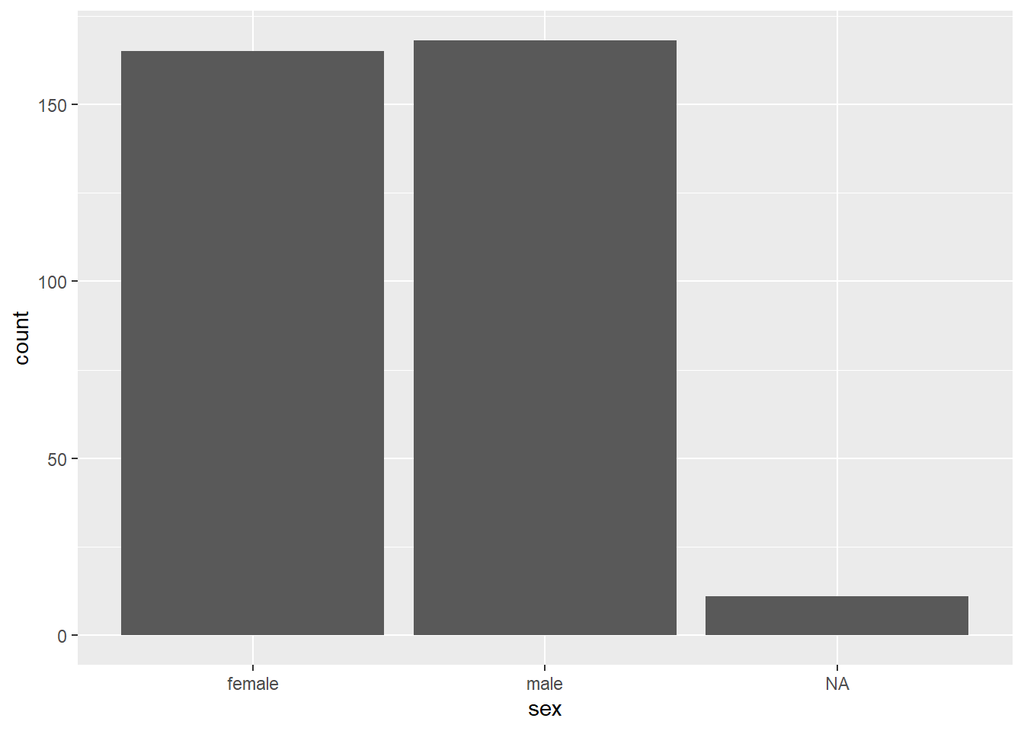

```r
# create plot
ggplot(penguins_count) + geom_bar(aes(x = sex, y = count), stat = "identity")
```